# APM1205 Formative Assessment 2: Linear Models

# 1. Introduction

This assessment uses the `Advertising` dataset to examine the relationship between television advertising expenditure and product sales. The predictor variable is TV advertising expenditure, while the response variable is Sales.

The purpose is to fit a simple linear regression model and use it to describe the relationship between TV advertising and Sales.

# 2. Data Preparation

The dataset contains 200 observations. The variables used in this analysis are:

- **TV** – television advertising expenditure, measured in thousands of dollars.
- **Sales** – product sales, measured in thousands of units.

```r
nrow(advertising)
```

```
## [1] 200
```

```r
head(advertising)
```

```
##        TV radio newspaper sales    fitted  residuals
## 1 1 230.1  37.8      69.2  22.1 17.970775  4.1292255
## 2 2  44.5  39.3      45.1  10.4  9.147974  1.2520260
## 3 3  17.2  45.9      69.3   9.3  7.850224  1.4497762
## 4 4 151.5  41.3      58.5  18.5 14.234395  4.2656054
## 5 5 180.8  10.8      58.4  12.9 15.627218 -2.7272181
## 6 6   8.7  48.9      75.0   7.2  7.446162 -0.2461623
```

```r
summary(advertising[, c(tv_col[1], sales_col[1])])
```

```
##        TV             sales
##  Min.   :  0.70   Min.   : 1.60
##  1st Qu.: 74.38   1st Qu.:10.38
##  Median :149.75   Median :12.90
##  Mean   :147.04   Mean   :14.02
##  3rd Qu.:218.82   3rd Qu.:17.40
##  Max.   :296.40   Max.   :27.00
```

# 3. Scatterplot of TV Advertising and Sales

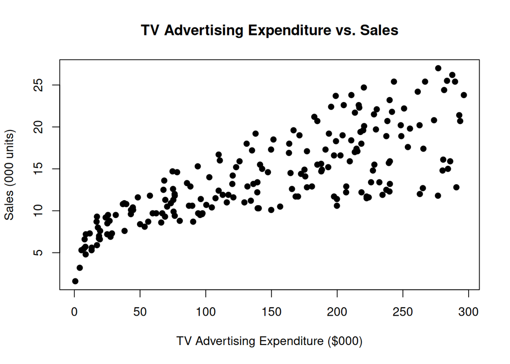

```r
plot(
  TV,
  Sales,
  main = "TV Advertising Expenditure vs. Sales",
  xlab = "TV Advertising Expenditure ($000)",
  ylab = "Sales (000 units)",
  pch = 19
)
```

The scatterplot shows a positive relationship between TV advertising expenditure and Sales. In general, observations with greater TV advertising expenditure tend to have greater sales.

# 4. Simple Linear Regression Model

The simple linear regression model is

$$Y = \beta_0 + \beta_1X + \epsilon$$

where $Y$ represents Sales and $X$ represents TV advertising expenditure.

```r
model
```

```
##
## Call:
## lm(formula = Sales ~ TV)
##
## Coefficients:
## (Intercept)           TV
##     7.03259      0.04754
```

The estimated regression equation is:

$$\widehat{Sales}
=
7.032594 + 0.04753664(TV)$$

Thus,

- Intercept = **7.032594**
- Slope = **0.04753664**

The intercept means that when TV advertising expenditure is 0, the predicted Sales is approximately 7.033 thousand units.

The slope means that for every additional $1,000 spent on TV advertising, predicted Sales increases by approximately 0.04754 thousand units, or about 47.54 units on average.

This describes an association between TV advertising and Sales and does not by itself establish that TV advertising causes the increase in Sales.

# 5. Fitted Values and Residuals

A fitted value is the predicted value of Sales from the regression equation:

$$\widehat{Y}_i = 7.032594 + 0.04753664X_i$$

A residual is the difference between the observed and fitted values:

$$e_i = Y_i-\widehat{Y}_i$$

```r
results <- data.frame(
  TV = TV,
  Sales = Sales,
  Fitted = advertising$fitted,
  Residual = advertising$residuals
)

head(results, 10)
```

```
##       TV Sales    Fitted   Residual
## 1  230.1  22.1 17.970775  4.1292255
## 2   44.5  10.4  9.147974  1.2520260
## 3   17.2   9.3  7.850224  1.4497762
## 4  151.5  18.5 14.234395  4.2656054
## 5  180.8  12.9 15.627218 -2.7272181
## 6    8.7   7.2  7.446162 -0.2461623
## 7   57.5  11.8  9.765950  2.0340496
## 8  120.2  13.2 12.746498  0.4535023
## 9    8.6   4.8  7.441409 -2.6414087
## 10 199.8  10.6 16.530414 -5.9304143
```

For example, for the first observation:

$$\widehat{Sales}
=
7.032594 + 0.04753664(230.1)$$

$$\widehat{Sales} \approx 17.9708$$

The observed Sales value is 22.1, so the residual is:

$$e = 22.1-17.9708 \approx 4.1292$$

A positive residual means that the observed Sales is greater than the model’s predicted Sales, while a negative residual means that the observed Sales is lower than the prediction.

# 6. Regression Line

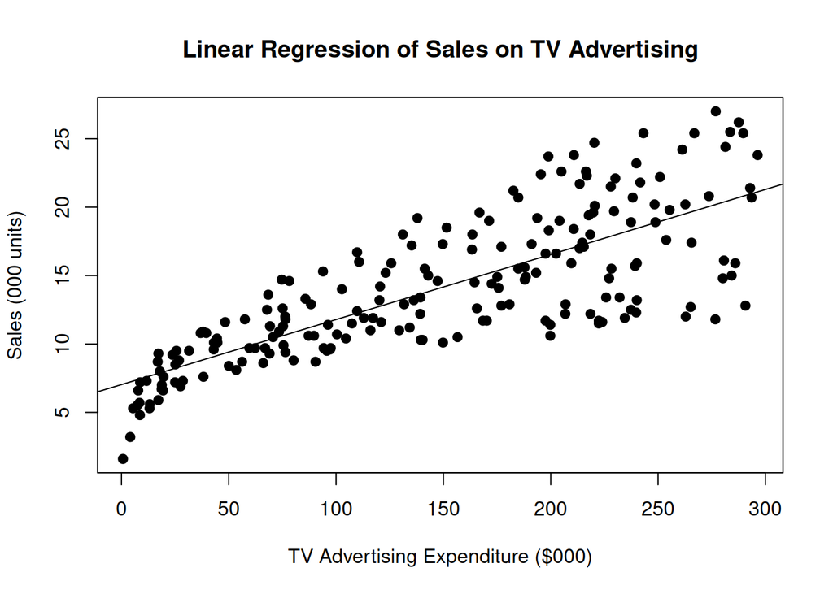

```r
plot(
  TV,
  Sales,
  main = "Linear Regression of Sales on TV Advertising",
  xlab = "TV Advertising Expenditure ($000)",
  ylab = "Sales (000 units)",
  pch = 19
)

abline(model)
```

The fitted line represents the predicted Sales values based on TV advertising expenditure.

# 7. Residual Plot

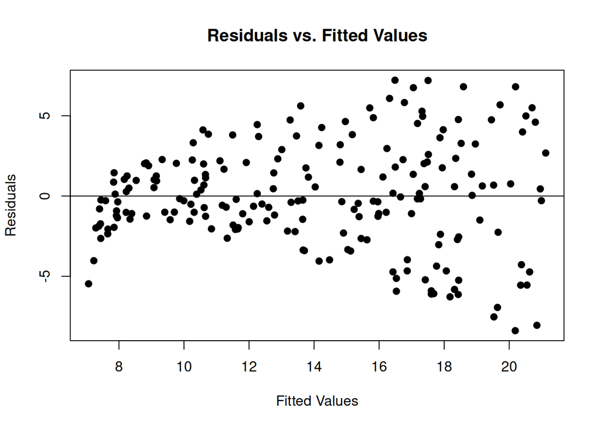

```r
plot(
  advertising$fitted,
  advertising$residuals,
  main = "Residuals vs. Fitted Values",
  xlab = "Fitted Values",
  ylab = "Residuals",
  pch = 19
)

abline(h = 0)
```

The residual plot can be used to examine whether there are noticeable patterns in the residuals. Ideally, the residuals should be scattered around zero without a clear systematic pattern.

# 8. Residual Standard Error

```r
model_summary <- summary(model)

model_summary$sigma
```

```
## [1] 3.258656
```

The residual standard error is approximately:

$$\boxed{3.258656}$$

This means that the typical size of the prediction error is approximately 3.26 thousand units of Sales.

# 9. Total Sum of Squares, Residual Sum of Squares, and Regression Sum of Squares

The total variation in Sales is measured by the Total Sum of Squares (TSS):

$$TSS = \sum (Y_i-\bar{Y})^2$$

The unexplained variation is measured by the Residual Sum of Squares (RSS):

$$RSS = \sum (Y_i-\widehat{Y}_i)^2$$

The explained variation is measured by the Regression Sum of Squares (RegSS):

$$RegSS = \sum (\widehat{Y}_i-\bar{Y})^2$$

```r
TSS <- sum((Sales - mean(Sales))^2)
RSS <- sum((Sales - advertising$fitted)^2)
RegSS <- sum((advertising$fitted - mean(Sales))^2)

TSS
```

```
## [1] 5417.149
```

```r
RSS
```

```
## [1] 2102.531
```

```r
RegSS
```

```
## [1] 3314.618
```

The results are approximately:

$$TSS = 5417.148750$$

$$RSS = 2102.530583$$

$$RegSS = 3314.618167$$

These satisfy the relationship:

$$TSS = RegSS + RSS$$

or approximately,

$$5417.148750
=
3314.618167 + 2102.530583$$

Therefore, the total variation in Sales is separated into the variation explained by the regression model and the remaining unexplained variation.

# 10. Correlation Coefficient

The correlation coefficient measures the strength and direction of the linear relationship between TV advertising expenditure and Sales.

```r
r <- cor(TV, Sales)

r
```

```
## [1] 0.7822244
```

The correlation coefficient is approximately:

$$\boxed{r = 0.782224}$$

The positive value indicates a positive linear association between TV advertising expenditure and Sales. Its magnitude indicates that the two variables have a substantial positive linear relationship.

# 11. Coefficient of Determination

The coefficient of determination is calculated as:

$$R^2 = r^2$$

```r
r_squared <- r^2

r_squared
```

```
## [1] 0.6118751
```

The coefficient of determination is approximately:

$$\boxed{R^2 = 0.611875}$$

This means that approximately **61.19% of the variation in Sales is explained by TV advertising expenditure in this simple linear regression model**.

The remaining approximately 38.81% is associated with variation not explained by TV advertising alone.

# 12. Model Summary

```r
summary(model)
```

```
##
## Call:
## lm(formula = Sales ~ TV)
##
## Residuals:
##     Min      1Q  Median      3Q     Max
## -8.3860 -1.9545 -0.1913  2.0671  7.2124
##
## Coefficients:
##             Estimate Std. Error t value Pr(>|t|)
## (Intercept) 7.032594   0.457843   15.36   <2e-16 ***
## TV          0.047537   0.002691   17.67   <2e-16 ***
## ---
## Signif. codes:  0 '***' 0.001 '**' 0.01 '*' 0.05 '.' 0.1 ' ' 1
##
## Residual standard error: 3.259 on 198 degrees of freedom
## Multiple R-squared:  0.6119, Adjusted R-squared:  0.6099
## F-statistic: 312.1 on 1 and 198 DF,  p-value: < 2.2e-16
```

The estimated model is:

$$\boxed{
\widehat{Sales}
=
7.032594 + 0.04753664(TV)
}$$

The model has a residual standard error of approximately 3.259 and an $R^2$ of approximately 0.612.

The positive slope indicates that higher TV advertising expenditure is associated with higher predicted Sales.

# 13. Conclusion

The analysis shows a positive linear relationship between TV advertising expenditure and Sales. The fitted regression equation is

$$\widehat{Sales}
=
7.032594 + 0.04753664(TV).$$

The correlation coefficient is approximately 0.782, indicating a positive linear association. The coefficient of determination is approximately 0.612, meaning that about 61.19% of the variation in Sales is explained by TV advertising expenditure in the fitted model.

The residual standard error is approximately 3.259 thousand units, representing the typical size of the prediction error. Overall, the simple linear regression provides a way to describe and predict Sales from TV advertising expenditure, while the results should be interpreted as an association rather than proof of causation.